# Collect radial measurements from a calcified structure by interactively selecting annuli

# 5 Examine Multiple Reads of the Same Structure

In some instances, one may be interested in visually comparing the selected points from multiple readings of the same structure. For example, the code below collects a second set of points for the “Scale_1.jpg” image.[^11] Note the different value in `reading=`.

```r
digitizeRadii("Scale_1.jpg",ID="1",reading="DHO2",edgeIsAnnulus=FALSE)
```

As shown above, `showDigitizedImage()` can be used to overlay the annular points onto the structure image. A second set of points can be overlaid onto the active plot by including `add=TRUE` in a second call to `showDigitizedImage()` with a second RData file name constructed from the same image. For example, the first line below overlays the annuli from the first selections onto the image. The second line then overlays the annuli from the second selections onto this image (because `add=TRUE`) and uses a different color for the transect and points.

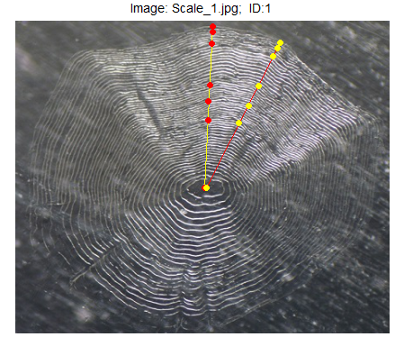

```r
showDigitizedImage("Scale_1_DHO.RData")
showDigitizedImage("Scale_1_DHO2.RData",add=TRUE,
                   col.transect="red",col.show="yellow")
```

# 6 Combine Data from Multiple Structures

## 6.1 File Organization

Of course, most analyses will consist of collecting radial measurements from structures from many fish. In this section, I demonstrate how to combine measurements from multiple structures. This demonstration assumes that all structure image files of interest are in the current working directory.[^12]

The `listFiles()` function may be used to identify all filenames in the current working directory that have a the file extension given in the first argument. For efficiency these filenames can be saved into an object (e.g., `fns`) as shown below.

```r
( fns <- listFiles("jpg") )
```

```
#> [1] "Scale_1.jpg" "Scale_2.jpg"
```

## 6.2 Processing Multiple Structure Images

```r
RFBCoptions(reading="DHO",edgeIsAnnulus=FALSE)
digitizeRadii(fns[1],ID="1")
digitizeRadii(fns[2],ID="2")
```

## 6.3 Combining Data Extracted from Multiple Structure Images

Once all structure image files have been processed, the radial measurements can be combined into one data.frame with `combineData()`. The first argument to this function is a vector of RData file names, which can be constructed using `listFiles()` with the `.RData` extension.

```r
( fns2 <- listFiles("RData") )
```

```
#> [1] "Scale_1_DHO.RData" "Scale_2_DHO.RData"
```

```r
( dfrad <- combineData(fns2) )
```

```
#>    ID reading ageCap ann       rad    radCap
#> 1   1     DHO      5   1 0.2141602 0.5143776
#> 2   1     DHO      5   2 0.2767637 0.5143776
#> 3   1     DHO      5   3 0.3289998 0.5143776
#> 4   1     DHO      5   4 0.4621417 0.5143776
#> 5   1     DHO      5   5 0.4974369 0.5143776
#> 6   1     DHO      5   6 0.5143776 0.5143776
#> 7   2     DHO      4   1 0.1665271 0.4385261
#> 8   2     DHO      4   2 0.2341519 0.4385261
#> 9   2     DHO      4   3 0.3220884 0.4385261
#> 10  2     DHO      4   4 0.3888447 0.4385261
#> 11  2     DHO      4   5 0.4385261 0.4385261
```

## 6.4 Preparing for Back-Calculations

Other information about the fish (e.g., location of capture, length, sex) is likely held in a separate file. Below, example “other” data are loaded into the `dffish` data.frame. Note that the `ID` and `reading` variables created from processing the structure images above are characters. In this case, `read.csv()` reads the `ID` variable from the external data file as numeric (because the unique IDs were simple numbers). The second line of code below converts these numeric IDs to characters so that this data.frame can be joined with the radial measurements data.frame from above.[^13]

```r
dffish <- read.csv("FishData.csv",stringsAsFactors=FALSE) %>%
  mutate(ID=as.character(ID)) %>%
  inner_join(dfrad,by="ID")
dffish
```

```
#>    ID  loc sex len reading ageCap ann       rad    radCap
#> 1   1 MI-5   M 189     DHO      5   1 0.2141602 0.5143776
#> 2   1 MI-5   M 189     DHO      5   2 0.2767637 0.5143776
#> 3   1 MI-5   M 189     DHO      5   3 0.3289998 0.5143776
#> 4   1 MI-5   M 189     DHO      5   4 0.4621417 0.5143776
#> 5   1 MI-5   M 189     DHO      5   5 0.4974369 0.5143776
#> 6   1 MI-5   M 189     DHO      5   6 0.5143776 0.5143776
#> 7   2 MI-6   F 210     DHO      4   1 0.1665271 0.4385261
#> 8   2 MI-6   F 210     DHO      4   2 0.2341519 0.4385261
#> 9   2 MI-6   F 210     DHO      4   3 0.3220884 0.4385261
#> 10  2 MI-6   F 210     DHO      4   4 0.3888447 0.4385261
#> 11  2 MI-6   F 210     DHO      4   5 0.4385261 0.4385261
```

```r
dffish2 <- spread(dffish,key=ann,value=rad,sep="rad")
dffish2
```

```
#>   ID  loc sex len reading ageCap    radCap   annrad1   annrad2   annrad3
#> 1  1 MI-5   M 189     DHO      5 0.5143776 0.2141602 0.2767637 0.3289998
#> 2  2 MI-6   F 210     DHO      4 0.4385261 0.1665271 0.2341519 0.3220884
#>     annrad4   annrad5   annrad6
#> 1 0.4621417 0.4974369 0.5143776
#> 2 0.3888447 0.4385261        NA
```

Either file can be written to a “comma-separated values” (CSV) file with `write.csv()` using the R object name (e.g., `dffish` or `dffish2` as the first argument and a name for the file in `file=`. Additionally, I prefer to have non-quoted values by using `quote=FALSE` and no row names by uwing `row.names=FALSE`. For example, the “one-measurement-per-line” data can be output to “Kiyi2014_BCs.csv” as follows.

```r
write.csv(dffish,file="Kiyi2014_BCs.csv",quote=FALSE,row.names=FALSE)
```

CSV files are small, portable, and can be opened directly in most spreadsheet softwares.

# 7 References

- Shoup, D.E., and P.H. Michaletz. 2017. Growth estimation: Summarization. Pages 233-264 in Quist, M.C. and D.A. Isermann, editors. Age and growth of fishes: principles and techniques. American Fisheries Society, Bethesda, MD.
- Vigliola, L., and M.G. Meekan. 2009. The back-calculation of fish growth from otoliths. Pages 174-211 in Green, B., B. Mapstone, G. Carlos, and G. Begg, editors. Tropical fish otoliths: information for assessment, management and ecology, volume 11. Springer, Dordrecht, Netherlands.

# 8 Footnotes